# Tests de modèles

### Les Librairies:

```python
import pandas as pd
import numpy as np
import matplotlib.pyplot as plt
import matplotlib.gridspec as gridspec
import seaborn as sns
from scipy import stats
import joblib
```

### Récupération des données

```python
data_clean =pd.read_csv("data_cleaned.csv")
```

```python
data_clean.shape
```

```
(1559, 22)
```

```python
data_clean.head()
```

|  | OSEBuildingID | BuildingType | PrimaryPropertyType | NumberofBuildings | NumberofFloors | PropertyGFATotal | PropertyGFAParking | PropertyGFABuilding(s) | LargestPropertyUseType | ENERGYSTARScore | ... | SiteEnergyUse(kBtu) | SteamUse(kBtu) | Electricity(kBtu) | NaturalGas(kBtu) | OtherFuelUse(kBtu) | TotalGHGEmissions | GHGEmissionsIntensity | Latitude | Longitude | BuildingAge |
| --- | --- | --- | --- | --- | --- | --- | --- | --- | --- | --- | --- | --- | --- | --- | --- | --- | --- | --- | --- | --- | --- |
| 0 | 400 | NonResidential | Office | 1.0 | 6.0 | 98370.0 | 25920.0 | 72450.0 | Office | 45.0 | ... | 15.691288 | 0.0 | 6488262.0 | 37893.0 | 0.0 | 3.876189 | 0.20 | 47.606799 | -122.337100 | 115 |
| 1 | 442 | NonResidential | Office | 1.0 | 4.0 | 193788.0 | 37854.0 | 155934.0 | Office | 59.0 | ... | 16.634519 | 0.0 | 16760914.0 | 0.0 | 0.0 | 4.769328 | 0.23 | 47.621476 | -122.343050 | 74 |
| 2 | 499 | NonResidential | Office | 1.0 | 3.0 | 76598.0 | 21410.0 | 55188.0 | Office | 76.0 | ... | 15.314463 | 0.0 | 2234200.0 | 2242889.0 | 0.0 | 4.910373 | 1.63 | 47.570897 | -122.297412 | 13 |
| 3 | 559 | NonResidential | Office | 1.0 | 4.0 | 186971.0 | 0.0 | 186971.0 | Office | 86.0 | ... | 16.354152 | 0.0 | 9657951.0 | 3004906.0 | 0.0 | 5.428995 | 0.99 | 47.621243 | -122.329786 | 40 |
| 4 | 714 | NonResidential | Office | 1.0 | 5.0 | 192960.0 | 32160.0 | 160800.0 | Office | 95.0 | ... | 15.713124 | 3054035.0 | 3616068.0 | 0.0 | 0.0 | 5.568115 | 1.27 | 47.603730 | -122.337367 | 110 |

5 rows × 22 columns

#### 1.Prétraitement

'OSEBuildingID' ne nous sera pas utile, nous la supprimerons du jeu de données.

```python
data_clean=data_clean.drop(['OSEBuildingID'], axis=1)
```

#### 1.1.sauvegarde séparée du energy star score

- 'ENERGYSTARScore': Nous allons l'écarter du dataset pour vérifier si cette variable a un impact sur la qualité de prédiction.

```python
energy_star_score = data_clean['ENERGYSTARScore']
data_clean.drop('ENERGYSTARScore', axis=1, inplace=True)
```

#### 1.2.Séparation des variables explicatives (features) et des étiquettes (targets)

Nous cherchons à élaborer un modèle de prédiction des émissions de CO2 et de la consommation totale d'énergie à partir d'un jeu de données.

#### Les variables cibles :

- 'TotalGHGEmissions': The total amount of greenhouse gas emissions, including carbon dioxide, methane, and nitrous oxide gases released into the atmosphere as a result of energy consumption at the property, measured in metric tons of carbon dioxide equivalent.
- 'SiteEnergyUse(kBtu)': The annual amount of energy consumed by the property from all sources of energy.

#### Préparation des jeux d'entrainement et de test

```python
# Features : toutes les colonnes, sauf les cibles et "ENERGYSTARScore" pour évaluation finale
X = data_clean.drop(['SiteEnergyUse(kBtu)','TotalGHGEmissions'], axis=1)

y = data_clean[['SiteEnergyUse(kBtu)','TotalGHGEmissions']]
```

```python
X.shape
```

```
(1559, 18)
```

```python
y.shape
```

```
(1559, 2)
```

#### 1.2. Préparation des données numériques et catégoriques

Les variables numériques doivent être standardisées et les variables catégoriques doivent être transformées en numérique

D’abord nous les séparons:

#### 1.2.1. Les variables numériques

```python
from sklearn.preprocessing import OneHotEncoder, StandardScaler
```

```python
numeric_columns = X.select_dtypes(include = ['int64','float64']).columns
```

```python
numeric_columns
```

```
Index(['NumberofBuildings', 'NumberofFloors', 'PropertyGFATotal',
       'PropertyGFAParking', 'PropertyGFABuilding(s)', 'SiteEUI(kBtu/sf)',
       'SourceEUI(kBtu/sf)', 'SteamUse(kBtu)', 'Electricity(kBtu)',
       'NaturalGas(kBtu)', 'OtherFuelUse(kBtu)', 'GHGEmissionsIntensity',
       'Latitude', 'Longitude', 'BuildingAge'],
      dtype='object')
```

#### Standardisation des variables numériques

```python
scaled_features = X.copy()
```

```python
scaler = StandardScaler()
X[numeric_columns] = scaler.fit_transform(X[numeric_columns])
```

#### 1.2.3. Les variables catégoriques

```python
category_columns = X.select_dtypes(include = ['object']).columns
```

```python
category_columns
```

```
Index(['BuildingType', 'PrimaryPropertyType', 'LargestPropertyUseType'], dtype='object')
```

```python
X=X.drop(['BuildingType','LargestPropertyUseType'], axis= 1)
```

```python
category_columns = X.select_dtypes(include = ['object']).columns
```

#### One-hot-encoding (transformation des variables catégoriques aux numériques)

```python
encoder = OneHotEncoder(sparse=False)

df= pd.DataFrame(data=encoder.fit_transform(X[category_columns]),
                       columns=encoder.get_feature_names())
```

```python
df.columns
```

```
Index(['x0_Education', 'x0_Food Sales & Service', 'x0_Healthcare',
       'x0_Lodging/Residential', 'x0_Mixed Use', 'x0_Office', 'x0_Other',
       'x0_Public Assembly', 'x0_Retail', 'x0_Technology/Science',
       'x0_Warehouse', 'x0_Warehouse/Storage'],
      dtype='object')
```

```python
X.columns
```

```
Index(['PrimaryPropertyType', 'NumberofBuildings', 'NumberofFloors',
       'PropertyGFATotal', 'PropertyGFAParking', 'PropertyGFABuilding(s)',
       'SiteEUI(kBtu/sf)', 'SourceEUI(kBtu/sf)', 'SteamUse(kBtu)',
       'Electricity(kBtu)', 'NaturalGas(kBtu)', 'OtherFuelUse(kBtu)',
       'GHGEmissionsIntensity', 'Latitude', 'Longitude', 'BuildingAge'],
      dtype='object')
```

Maintenant que les variables numériques et catégoriques sont prêtes, nous allons les mettre ensemble

#### 1.2.4. Fusionner les variables numériques et catégoriques

```python
X = pd.concat([X[numeric_columns], df], axis=1)
```

```python
X.shape
```

```
(1559, 27)
```

```python
X.head(2)
```

|  | NumberofBuildings | NumberofFloors | PropertyGFATotal | PropertyGFAParking | PropertyGFABuilding(s) | SiteEUI(kBtu/sf) | SourceEUI(kBtu/sf) | SteamUse(kBtu) | Electricity(kBtu) | NaturalGas(kBtu) | ... | x0_Healthcare | x0_Lodging/Residential | x0_Mixed Use | x0_Office | x0_Other | x0_Public Assembly | x0_Retail | x0_Technology/Science | x0_Warehouse | x0_Warehouse/Storage |
| --- | --- | --- | --- | --- | --- | --- | --- | --- | --- | --- | --- | --- | --- | --- | --- | --- | --- | --- | --- | --- | --- |
| 0 | -0.065008 | 0.654731 | 0.179007 | 0.573898 | 0.000832 | 0.040628 | 0.355316 | -0.18156 | 0.538503 | -0.161277 | ... | 0.0 | 0.0 | 0.0 | 1.0 | 0.0 | 0.0 | 0.0 | 0.0 | 0.0 | 0.0 |
| 1 | -0.065008 | 0.146021 | 1.203863 | 0.986463 | 1.061302 | 0.751390 | 1.246591 | -0.18156 | 2.295137 | -0.166186 | ... | 0.0 | 0.0 | 0.0 | 1.0 | 0.0 | 0.0 | 0.0 | 0.0 | 0.0 | 0.0 |

2 rows × 27 columns

#### 2. Modèle Baseline: DummyRegressor

Nous allons créer un modèle baseline pour évaluer les performances de nos futurs modèles et vérifier qu’ils améliorent les prédictions. Pour cette baseline, nous utiliserons une DummyRegressor.

```python
import timeit

start_time = timeit.default_timer()
```

```python
from sklearn.model_selection import train_test_split

X_train, X_test, y_train, y_test = train_test_split(X,y['SiteEnergyUse(kBtu)'], test_size=0.20, random_state=42)
```

```python
from sklearn.dummy import DummyRegressor
dummy_regr = DummyRegressor(strategy="mean")
```

```python
# Entrainement
dummy_regr.fit(X_train,  y_train)
```

```
DummyRegressor()
```

```python
# Prédiction sur le jeu de test
y_test_pred= dummy_regr.predict(X_test)
```

```python
# evaluation
import sklearn.metrics as metrics
Results = pd.DataFrame({})
rmse=metrics.mean_squared_error(y_test, y_test_pred, squared = False)
mae=metrics.mean_absolute_error(y_test, y_test_pred)
r2=metrics.r2_score(y_test, y_test_pred)
time = timeit.default_timer() - start_time
Results = Results.append({
    "Modèle" : "DummyRegressor",
    "RMSE": rmse,
    "MAE": mae,
    "R2": r2,
    "time": time
}, ignore_index = True)
Results
```

|  | MAE | Modèle | R2 | RMSE | time |
| --- | --- | --- | --- | --- | --- |
| 0 | 0.9636 | DummyRegressor | -0.000019 | 1.185507 | 13.136921 |

Nous allons donc réaliser nos premières modélisations :

#### 3.Prédiction de la consommation totale d'énergie (SiteEnergyUse)

#### Séparation des jeux de données d'entraînement et de test

Nous allons d'abord Séparer des jeux de données d'entraînement et de test. étant donné que les hyperparamètres et le modèle seront sélectionnées par une validation croisée, il n'est pas nécessaire de séparer jeux d'entraînement, de test et de validation.

```python
X_train, X_test, y_train, y_test = train_test_split(X,y['SiteEnergyUse(kBtu)'], test_size=0.20, shuffle=True, random_state=42)


print("Entrainement: {} lignes,\nTest: {} lignes.\n".format(X_train.shape[0],
                                                            X_test.shape[0]))
```

```
Entrainement: 1247 lignes,
Test: 312 lignes.
```

#### 3.1.Modèle ElasticNet (SiteEnergyUse)

```python
from sklearn.linear_model import ElasticNet
from sklearn.model_selection import GridSearchCV

parameters = {'tol' : [0.1,0.01,0.001,0.0001],  #critères d'arrêt
              # arrêt de rechercher un minimum (ou un maximum) une fois qu'une certaine tolérance est atteinte
              "alpha": [0.0001, 0.001, 0.01, 0.1, 1, 10, 100],
              "l1_ratio": np.arange(0.0, 1.0, 0.1)}


elastic_grid = GridSearchCV(estimator = ElasticNet(random_state= 42),
                            param_grid = parameters,
                            scoring='neg_root_mean_squared_error',
                            n_jobs=-1, #  le nombre de processus (tous les processeurs seront utilisés)
                            cv=5,
                            verbose=0
                            )

elastic_grid.fit(X_train, y_train)
```

```
GridSearchCV(cv=5, estimator=ElasticNet(random_state=42), n_jobs=-1,
             param_grid={'alpha': [0.0001, 0.001, 0.01, 0.1, 1, 10, 100],
                         'l1_ratio': array([0. , 0.1, 0.2, 0.3, 0.4, 0.5, 0.6, 0.7, 0.8, 0.9]),
                         'tol': [0.1, 0.01, 0.001, 0.0001]},
             scoring='neg_root_mean_squared_error')
```

```python
elastic_grid.best_params_
```

```
{'alpha': 0.1, 'l1_ratio': 0.30000000000000004, 'tol': 0.1}
```

l1_ratio est de 0.30, signifiant que le poids du L2 est plus important que celui du L1 dans la régularisation

```python
from sklearn.metrics import mean_squared_error
from sklearn.metrics import mean_absolute_error
from sklearn.metrics import r2_score

consommation_energy = pd.DataFrame({})

rmse = mean_squared_error(y_test, elastic_grid.predict(X_test), squared=False)
mae = mean_absolute_error(y_test, elastic_grid.predict(X_test))
r_squared = r2_score(y_test, elastic_grid.predict(X_test))
time = %timeit -o elastic_grid.best_estimator_.predict(X_test)

consommation_energy = consommation_energy.append(pd.DataFrame({'Modèle': ['LinearRegression'],
                                       'RMSE': rmse,
                                       'MAE': mae,
                                       'R²': r_squared,
                                       'Time_ms': time.best*1000,
                'Cv_score(RMSE)': -1 * elastic_grid.best_score_}),
                         ignore_index=True)
```

```
686 µs ± 22.7 µs per loop (mean ± std. dev. of 7 runs, 1000 loops each)
```

```python
consommation_energy
```

|  | Modèle | RMSE | MAE | R² | Time_ms | Cv_score(RMSE) |
| --- | --- | --- | --- | --- | --- | --- |
| 0 | LinearRegression | 0.672611 | 0.473024 | 0.678095 | 0.648237 | 0.691657 |

#### Coefficients de Elastic_Net

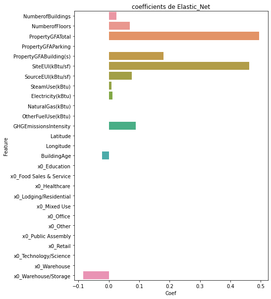

```python
elastic_Coef=pd.DataFrame({'Feature': X_test.columns,
              'Coef': elastic_grid.best_estimator_.coef_})
plt.figure(figsize=(7,10))
sns.barplot(x = elastic_Coef['Coef'],
            y = elastic_Coef['Feature'])
plt.title('coefficients de Elastic_Net')
```

#### 3.2.Modèle Support Vector Machine (SVM) - (SiteEnergyUse)

```python
from sklearn.svm import SVR

parameters = {'gamma' : [1e-8, 1e-7, 1e-6, 1e-5, 1e-4, 1e-3, 1e-2, 1e-1], # distance pour calcul de la ligne de séparation plausible
              'epsilon' : [0.001, 0.01, 0.1, 1], #erreur tolérée par l'algorithme
              'C' : [0.001, 0.01, 0.1, 1, 10]} # parametre de régularisation(le paramètre de pénalité)

svm = GridSearchCV(estimator = SVR(),
                      param_grid = parameters,
                      scoring='neg_root_mean_squared_error',
                      n_jobs=-1,
                      cv=5,
                      verbose=5
                     )

svm.fit(X_train, y_train)
```

```
Fitting 5 folds for each of 160 candidates, totalling 800 fits
```

```
GridSearchCV(cv=5, estimator=SVR(), n_jobs=-1,
             param_grid={'C': [0.001, 0.01, 0.1, 1, 10],
                         'epsilon': [0.001, 0.01, 0.1, 1],
                         'gamma': [1e-08, 1e-07, 1e-06, 1e-05, 0.0001, 0.001,
                                   0.01, 0.1]},
             scoring='neg_root_mean_squared_error', verbose=5)
```

```python
svm.best_params_
```

```
{'C': 10, 'epsilon': 0.001, 'gamma': 0.1}
```

```python
rmse = mean_squared_error(y_test, svm.predict(X_test), squared=False)
mae = mean_absolute_error(y_test, svm.predict(X_test))
r_squared = r2_score(y_test, svm.predict(X_test))
time = %timeit -o  svm.best_estimator_.predict(X_test)

consommation_energy = consommation_energy.append(pd.DataFrame({'Modèle': ['SVR'],
                                       'RMSE': rmse,
                                       'MAE': mae,
                                       'R²': r_squared,
                                       'Time_ms': time.best*1000,
                    'Cv_score(RMSE)': -1 * svm.best_score_}),
                         ignore_index=True)
```

```
32.3 ms ± 1.41 ms per loop (mean ± std. dev. of 7 runs, 10 loops each)
```

```python
consommation_energy
```

|  | Modèle | RMSE | MAE | R² | Time_ms | Cv_score(RMSE) |
| --- | --- | --- | --- | --- | --- | --- |
| 0 | LinearRegression | 0.672611 | 0.473024 | 0.678095 | 0.648237 | 0.691657 |
| 1 | SVR | 0.259366 | 0.130586 | 0.952134 | 30.054190 | 0.395358 |

#### 3.3. Modèle Random Forest Regressor (SiteEnergyUse)

```python
from sklearn.ensemble import RandomForestRegressor
parameters = {
    'n_estimators' : [100, 300, 500],  #nombre d'arbres de décision

    'min_samples_leaf' : [1, 2, 5],
    #nombre de feuilles minimales dans un noeud
    'max_features': ['auto', 'sqrt']
    #nombre de features observées par arbre
}

R_Forest_grid = GridSearchCV(RandomForestRegressor(random_state=42),
                        param_grid=parameters,
                        scoring='neg_root_mean_squared_error',
                        n_jobs=-1,
                        verbose=5,
                        cv=5)

R_Forest_grid.fit(X_train, y_train)
```

```
Fitting 5 folds for each of 18 candidates, totalling 90 fits
```

```
GridSearchCV(cv=5, estimator=RandomForestRegressor(random_state=42), n_jobs=-1,
             param_grid={'max_features': ['auto', 'sqrt'],
                         'min_samples_leaf': [1, 2, 5],
                         'n_estimators': [100, 300, 500]},
             scoring='neg_root_mean_squared_error', verbose=5)
```

```python
R_Forest_grid.best_params_
```

```
{'max_features': 'auto', 'min_samples_leaf': 1, 'n_estimators': 300}
```

```python
coefficients = abs(R_Forest_grid.best_estimator_.feature_importances_)
liste_coefs_rer = pd.concat((pd.DataFrame(X.columns, columns = ['Variable']),
                      pd.DataFrame(coefficients, columns = ['Coefficient'])), axis = 1).sort_values(by='Coefficient', ascending = False)
```

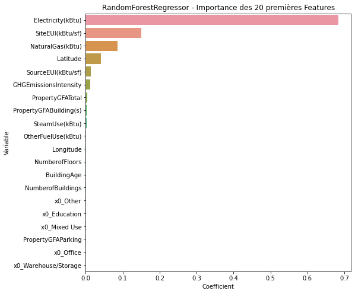

```python
plt.figure(figsize=(8,8))
plt.title('RandomForestRegressor - Importance des 20 premières Features')
sns.barplot(y = liste_coefs_rer['Variable'].head(20),
            x = liste_coefs_rer['Coefficient'].head(20))
plt.show()
```

```python
R_Forest_grid.best_score_
```

```
-0.30608283420471705
```

```python
rmse = mean_squared_error(y_test, R_Forest_grid.predict(X_test), squared=False)
mae = mean_absolute_error(y_test, R_Forest_grid.predict(X_test))
r_squared = r2_score(y_test, R_Forest_grid.predict(X_test))
time = %timeit -o  R_Forest_grid.best_estimator_.predict(X_test)
consommation_energy = consommation_energy.append(pd.DataFrame({'Modèle': ['Random Forest Regressor'],
                                       'RMSE': rmse,
                                       'MAE': mae,
                                       'R²': r_squared,
                                       'Time_ms': time.best*1000,
                    'Cv_score(RMSE)': -1 * R_Forest_grid.best_score_}),
                         ignore_index=True)
```

```
25.1 ms ± 907 µs per loop (mean ± std. dev. of 7 runs, 10 loops each)
```

```python
consommation_energy
```

|  | Modèle | RMSE | MAE | R² | Time_ms | Cv_score(RMSE) |
| --- | --- | --- | --- | --- | --- | --- |
| 0 | LinearRegression | 0.672611 | 0.473024 | 0.678095 | 0.648237 | 0.691657 |
| 1 | SVR | 0.259366 | 0.130586 | 0.952134 | 30.054190 | 0.395358 |
| 2 | Random Forest Regressor | 0.152886 | 0.065093 | 0.983368 | 24.106660 | 0.306083 |

#### 3.4.Modèle XGBoost (SiteEnergyUse)

```python
from xgboost import XGBRegressor
from sklearn.ensemble import GradientBoostingRegressor
```

```python
parameters = {
    'loss': ['ls', 'lad'],
    'n_estimators': [100, 200, 300],
    'min_samples_leaf': [1, 2, 5, 8, 12],
    'max_features': ['auto', 'sqrt'],
    'criterion': ['mse'],
}

xgb_grid = GridSearchCV(GradientBoostingRegressor(random_state= 42),
                        param_grid = parameters,
                        scoring='neg_root_mean_squared_error',
                        n_jobs = -1,
                        cv = 5,
                        verbose=5)

xgb_grid.fit(X_train, y_train)
```

```
Fitting 5 folds for each of 60 candidates, totalling 300 fits
```

```
GridSearchCV(cv=5, estimator=GradientBoostingRegressor(random_state=42),
             n_jobs=-1,
             param_grid={'criterion': ['mse'], 'loss': ['ls', 'lad'],
                         'max_features': ['auto', 'sqrt'],
                         'min_samples_leaf': [1, 2, 5, 8, 12],
                         'n_estimators': [100, 200, 300]},
             scoring='neg_root_mean_squared_error', verbose=5)
```

```python
xgb_grid.best_params_
```

```
{'criterion': 'mse',
 'loss': 'lad',
 'max_features': 'auto',
 'min_samples_leaf': 8,
 'n_estimators': 300}
```

```python
coefficients = abs(xgb_grid.best_estimator_.feature_importances_)
liste_coefs_rer = pd.concat((pd.DataFrame(X.columns, columns = ['Variable']),
                      pd.DataFrame(coefficients, columns = ['Coefficient'])),
                       axis = 1).sort_values(by='Coefficient',
                                             ascending = False)
```

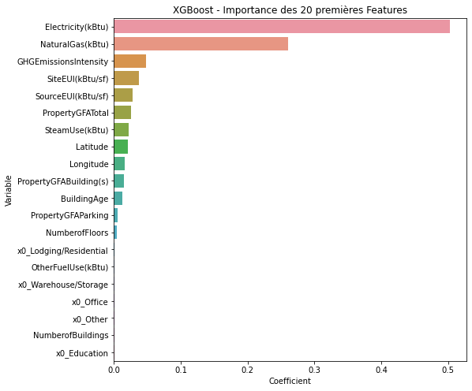

```python
plt.figure(figsize=(8,8))
plt.title('XGBoost - Importance des 20 premières Features')
sns.barplot(y = liste_coefs_rer['Variable'].head(20),
            x = liste_coefs_rer['Coefficient'].head(20))
plt.show()
```

```python
xgb_grid.best_score_
```

```
-0.27832673794707713
```

```python
rmse = mean_squared_error(y_test, xgb_grid.predict(X_test), squared=False)
mae = mean_absolute_error(y_test, xgb_grid.predict(X_test))
r_squared = r2_score(y_test, xgb_grid.predict(X_test))
time = %timeit -o  xgb_grid.best_estimator_.predict(X_test)

consommation_energy = consommation_energy.append(pd.DataFrame({'Modèle': ['XGBoost'],
                                       'RMSE': rmse,
                                       'MAE': mae,
                                       'R²': r_squared,
                                       'Time_ms': time.best*1000,
                    'Cv_score(RMSE)': -1 * xgb_grid.best_score_}),
                         ignore_index=True)
```

```
1.72 ms ± 29.1 µs per loop (mean ± std. dev. of 7 runs, 1000 loops each)
```

```python
consommation_energy
```

|  | Modèle | RMSE | MAE | R² | Time_ms | Cv_score(RMSE) |
| --- | --- | --- | --- | --- | --- | --- |
| 0 | LinearRegression | 0.672611 | 0.473024 | 0.678095 | 0.648237 | 0.691657 |
| 1 | SVR | 0.259366 | 0.130586 | 0.952134 | 30.054190 | 0.395358 |
| 2 | Random Forest Regressor | 0.152886 | 0.065093 | 0.983368 | 24.106660 | 0.306083 |
| 3 | XGBoost | 0.130016 | 0.064942 | 0.987972 | 1.662944 | 0.278327 |

```python
consommation_energy = consommation_energy.sort_values(by='R²', ascending=False)
consommation_energy
```

|  | Modèle | RMSE | MAE | R² | Time_ms | Cv_score(RMSE) |
| --- | --- | --- | --- | --- | --- | --- |
| 3 | XGBoost | 0.130016 | 0.064942 | 0.987972 | 1.662944 | 0.278327 |
| 2 | Random Forest Regressor | 0.152886 | 0.065093 | 0.983368 | 24.106660 | 0.306083 |
| 1 | SVR | 0.259366 | 0.130586 | 0.952134 | 30.054190 | 0.395358 |
| 0 | LinearRegression | 0.672611 | 0.473024 | 0.678095 | 0.648237 | 0.691657 |

#### - Le meilleur modèle choisi: XGBoost

Nous allons choisir XGBoost, comme le meilleur modèle de prédiction de la consommation d’Energie

```python
comparaison = pd.melt(consommation_energy.reset_index(), id_vars = ['Modèle'], value_name = 'score', value_vars=["RMSE","MAE","R²","Time_ms"])
```

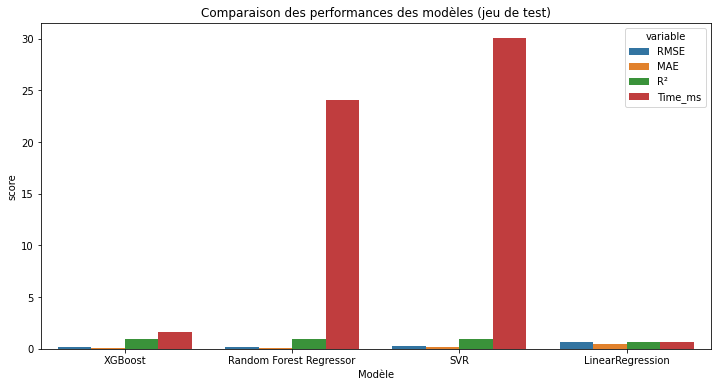

```python
plt.figure(figsize=(12,6))
sns.barplot(x = comparaison['Modèle'],
            y = comparaison['score'], hue = comparaison['variable'])
plt.title('Comparaison des performances des modèles (jeu de test)')
```

```python
xgb_grid.best_params_
```

```
{'criterion': 'mse',
 'loss': 'lad',
 'max_features': 'auto',
 'min_samples_leaf': 8,
 'n_estimators': 300}
```

#### sauvegarde les paramètres de meilleur modèle

```python
best_param = xgb_grid.best_params_

for i in best_param:
  best_param[i] = list([best_param[i]])

joblib.dump(best_param, 'best_param_xgb_consomation.sav')
```

```
['best_param_xgb_consomation.sav']
```

#### 4.Prédiction de l’émission de CO2 (TotalGHGEmissions)

```python
X_train, X_test, y_train, y_test = train_test_split(X,y['TotalGHGEmissions'],
                                         test_size=0.20,
                                         shuffle=True, # mélanger les données avant de les diviser
                                         random_state=42,
                                         )
print("Entrainement: {} lignes,\nTest: {} lignes.\n".format(X_train.shape[0],
                                                            X_test.shape[0]))
```

```
Entrainement: 1247 lignes,
Test: 312 lignes.
```

#### 4.1. Modèle ElasticNet (TotalGHGEmissions)

```python
parameters = {'tol' : [0.1,0.01,0.001,0.0001],  #critères d'arrêt
              # arrêt de rechercher un minimum (ou un maximum) une fois qu'une certaine tolérance est atteinte,
              "alpha": [0.0001, 0.001, 0.01, 0.1, 1, 10, 100],
              "l1_ratio": np.arange(0.0, 1.0, 0.1)}


elastic_grid = GridSearchCV(estimator = ElasticNet(random_state= 42),
                            param_grid = parameters,
                            scoring='neg_root_mean_squared_error',
                            n_jobs=-1, #  le nombre de processus (tous les processeurs seront utilisés)
                            cv=5,
                            verbose=0
                            )

elastic_grid.fit(X_train, y_train)
```

```
GridSearchCV(cv=5, estimator=ElasticNet(random_state=42), n_jobs=-1,
             param_grid={'alpha': [0.0001, 0.001, 0.01, 0.1, 1, 10, 100],
                         'l1_ratio': array([0. , 0.1, 0.2, 0.3, 0.4, 0.5, 0.6, 0.7, 0.8, 0.9]),
                         'tol': [0.1, 0.01, 0.001, 0.0001]},
             scoring='neg_root_mean_squared_error')
```

```python
elastic_grid.best_params_
```

```
{'alpha': 0.1, 'l1_ratio': 0.6000000000000001, 'tol': 0.01}
```

```python
emissions_CO2 = pd.DataFrame({})

rmse = mean_squared_error(y_test, elastic_grid.predict(X_test), squared=False)
mae = mean_absolute_error(y_test, elastic_grid.predict(X_test))
r_squared = r2_score(y_test, elastic_grid.predict(X_test))
time = %timeit -o elastic_grid.best_estimator_.predict(X_test)

emissions_CO2 = emissions_CO2.append(pd.DataFrame({'Modèle': ['LinearRegression'],
                                       'RMSE': rmse,
                                       'MAE': mae,
                                       'R²': r_squared,
                                       'Time_ms': time.best*1000,
                'Cv_score(RMSE)': -1 * elastic_grid.best_score_}),
                         ignore_index=True)
```

```
668 µs ± 11.8 µs per loop (mean ± std. dev. of 7 runs, 1000 loops each)
```

```python
emissions_CO2
```

|  | Modèle | RMSE | MAE | R² | Time_ms | Cv_score(RMSE) |
| --- | --- | --- | --- | --- | --- | --- |
| 0 | LinearRegression | 0.883711 | 0.649457 | 0.543104 | 0.654558 | 0.777396 |

#### Coefficients de Elastic_Net

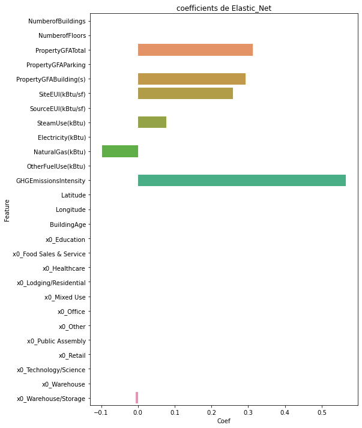

```python
elastic_Coef=pd.DataFrame({'Feature': X_test.columns,
              'Coef': elastic_grid.best_estimator_.coef_})

plt.figure(figsize=(8,12))
sns.barplot(x = elastic_Coef['Coef'],
            y = elastic_Coef['Feature'])
plt.title('coefficients de Elastic_Net')
```

#### 4.2.Modèle Support Vector Machine (SVM)- (TotalGHGEmissions)

```python
parameters = {'gamma' : [1e-8, 1e-7, 1e-6, 1e-5, 1e-4, 1e-3, 1e-2, 1e-1], #kernel coefficient [ici kernel = Radial Basis Function]
              'epsilon' : [0.001, 0.01, 0.1, 1], #erreur tolérée par l'algorithme
              'C' : [0.001, 0.01, 0.1, 1, 10]} #parametre de régularisation

svm = GridSearchCV(estimator = SVR(),
                      param_grid = parameters,
                      scoring='neg_root_mean_squared_error',
                      n_jobs=-1,
                      cv=5,
                      verbose=5
                     )

svm.fit(X_train, y_train)
```

```
Fitting 5 folds for each of 160 candidates, totalling 800 fits
```

```
GridSearchCV(cv=5, estimator=SVR(), n_jobs=-1,
             param_grid={'C': [0.001, 0.01, 0.1, 1, 10],
                         'epsilon': [0.001, 0.01, 0.1, 1],
                         'gamma': [1e-08, 1e-07, 1e-06, 1e-05, 0.0001, 0.001,
                                   0.01, 0.1]},
             scoring='neg_root_mean_squared_error', verbose=5)
```

```python
svm.best_params_
```

```
{'C': 10, 'epsilon': 0.01, 'gamma': 0.1}
```

```python
rmse = mean_squared_error(y_test, svm.predict(X_test), squared=False)
mae = mean_absolute_error(y_test, svm.predict(X_test))
r_squared = r2_score(y_test, svm.predict(X_test))
time = %timeit -o  svm.best_estimator_.predict(X_test)

emissions_CO2 = emissions_CO2.append(pd.DataFrame({'Modèle': ['SVR'],
                                       'RMSE': rmse,
                                       'MAE': mae,
                                       'R²': r_squared,
                                       'Time_ms': time.best*1000,
                    'Cv_score(RMSE)': -1 * svm.best_score_}),
                         ignore_index=True)
```

```
29.9 ms ± 1.62 ms per loop (mean ± std. dev. of 7 runs, 10 loops each)
```

```python
emissions_CO2
```

|  | Modèle | RMSE | MAE | R² | Time_ms | Cv_score(RMSE) |
| --- | --- | --- | --- | --- | --- | --- |
| 0 | LinearRegression | 0.883711 | 0.649457 | 0.543104 | 0.654558 | 0.777396 |
| 1 | SVR | 0.309706 | 0.189208 | 0.943883 | 27.640650 | 0.342220 |

#### 4.3. Modèle Random Forest Regressor (TotalGHGEmissions)

```python
parameters = {
    'n_estimators' : [100, 300, 500],  #nombre d'arbres de décision

    'min_samples_leaf' : [1, 2, 5],
    #nombre de feuilles minimales dans un noeud
    'max_features': ['auto', 'sqrt']
    #nombre de features observées par arbre
}

R_Forest_grid = GridSearchCV(RandomForestRegressor(random_state=42),
                        param_grid=parameters,
                        scoring='neg_root_mean_squared_error',
                        n_jobs=-1,
                        verbose=5,
                        cv=5)

R_Forest_grid.fit(X_train, y_train)
```

```
Fitting 5 folds for each of 18 candidates, totalling 90 fits
```

```
GridSearchCV(cv=5, estimator=RandomForestRegressor(random_state=42), n_jobs=-1,
             param_grid={'max_features': ['auto', 'sqrt'],
                         'min_samples_leaf': [1, 2, 5],
                         'n_estimators': [100, 300, 500]},
             scoring='neg_root_mean_squared_error', verbose=5)
```

```python
R_Forest_grid.best_params_
```

```
{'max_features': 'auto', 'min_samples_leaf': 1, 'n_estimators': 500}
```

```python
coefficients = abs(R_Forest_grid.best_estimator_.feature_importances_)
liste_coefs_rer = pd.concat((pd.DataFrame(X.columns, columns = ['Variable']),
                      pd.DataFrame(coefficients, columns = ['Coefficient'])), axis = 1).sort_values(by='Coefficient', ascending = False)
```

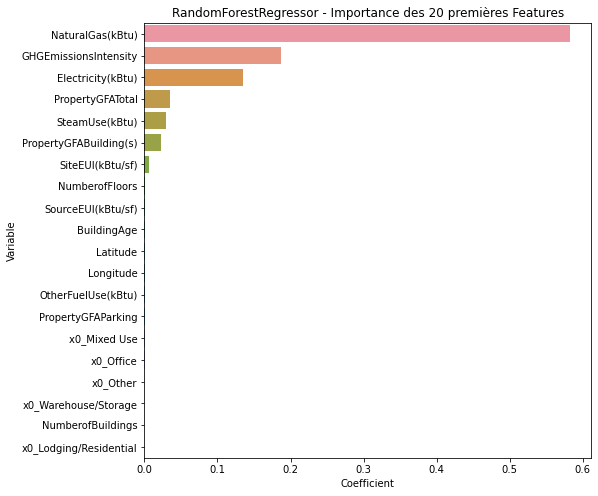

```python
plt.figure(figsize=(8,8))
plt.title('RandomForestRegressor - Importance des 20 premières Features')
sns.barplot(y = liste_coefs_rer['Variable'].head(20),
            x = liste_coefs_rer['Coefficient'].head(20))
plt.show()
```

```python
R_Forest_grid.best_score_
```

```
-0.12775854822345217
```

```python
rmse = mean_squared_error(y_test, R_Forest_grid.predict(X_test), squared=False)
mae = mean_absolute_error(y_test, R_Forest_grid.predict(X_test))
r_squared = r2_score(y_test, R_Forest_grid.predict(X_test))
time = %timeit -o  R_Forest_grid.best_estimator_.predict(X_test)
emissions_CO2 = emissions_CO2.append(pd.DataFrame({'Modèle': ['Random Forest Regressor'],
                                       'RMSE': rmse,
                                       'MAE': mae,
                                       'R²': r_squared,
                                       'Time_ms': time.best*1000,
                    'Cv_score(RMSE)': -1 * R_Forest_grid.best_score_}),
                         ignore_index=True)
```

```
40.2 ms ± 1.09 ms per loop (mean ± std. dev. of 7 runs, 10 loops each)
```

```python
emissions_CO2
```

|  | Modèle | RMSE | MAE | R² | Time_ms | Cv_score(RMSE) |
| --- | --- | --- | --- | --- | --- | --- |
| 0 | LinearRegression | 0.883711 | 0.649457 | 0.543104 | 0.654558 | 0.777396 |
| 1 | SVR | 0.309706 | 0.189208 | 0.943883 | 27.640650 | 0.342220 |
| 2 | Random Forest Regressor | 0.093891 | 0.054754 | 0.994842 | 38.512940 | 0.127759 |

#### 4.4. Modèle XGBoost (TotalGHGEmissions)

```python
parameters = {
    'loss': ['ls', 'lad'],
    'n_estimators': [100, 200, 300],
    'min_samples_leaf': [1, 2, 5, 8, 12],
    'max_features': ['auto', 'sqrt'],
    'criterion': ['mse'],
}

xgb_grid_co2 = GridSearchCV(GradientBoostingRegressor(random_state=0),
                        param_grid = parameters,
                        scoring='neg_root_mean_squared_error',
                        n_jobs = -1,
                        cv = 5,
                        verbose=5)

xgb_grid_co2.fit(X_train, y_train)
```

```
Fitting 5 folds for each of 60 candidates, totalling 300 fits
```

```
GridSearchCV(cv=5, estimator=GradientBoostingRegressor(random_state=0),
             n_jobs=-1,
             param_grid={'criterion': ['mse'], 'loss': ['ls', 'lad'],
                         'max_features': ['auto', 'sqrt'],
                         'min_samples_leaf': [1, 2, 5, 8, 12],
                         'n_estimators': [100, 200, 300]},
             scoring='neg_root_mean_squared_error', verbose=5)
```

```python
xgb_grid_co2.best_params_
```

```
{'criterion': 'mse',
 'loss': 'ls',
 'max_features': 'auto',
 'min_samples_leaf': 1,
 'n_estimators': 300}
```

```python
coefficients = abs(xgb_grid_co2.best_estimator_.feature_importances_)
liste_coefs_rer = pd.concat((pd.DataFrame(X.columns, columns = ['Variable']),
                      pd.DataFrame(coefficients, columns = ['Coefficient'])),
                       axis = 1).sort_values(by='Coefficient',
                                             ascending = False)
```

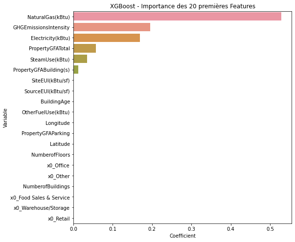

```python
plt.figure(figsize=(8,8))
plt.title('XGBoost - Importance des 20 premières Features')
sns.barplot(y = liste_coefs_rer['Variable'].head(20),
            x = liste_coefs_rer['Coefficient'].head(20))
plt.show()
```

```python
rmse = mean_squared_error(y_test, xgb_grid_co2.predict(X_test), squared=False)
mae = mean_absolute_error(y_test, xgb_grid_co2.predict(X_test))
r_squared = r2_score(y_test, xgb_grid_co2.predict(X_test))
time = %timeit -o  xgb_grid_co2.best_estimator_.predict(X_test)

emissions_CO2 = emissions_CO2.append(pd.DataFrame({'Modèle': ['XGBoost'],
                                       'RMSE': rmse,
                                       'MAE': mae,
                                       'R²': r_squared,
                                       'Time_ms': time.best*1000,
                    'Cv_score(RMSE)': -1 * xgb_grid_co2.best_score_}),
                         ignore_index=True)
```

```
2.29 ms ± 276 µs per loop (mean ± std. dev. of 7 runs, 100 loops each)
```

```python
emissions_CO2
```

|  | Modèle | RMSE | MAE | R² | Time_ms | Cv_score(RMSE) |
| --- | --- | --- | --- | --- | --- | --- |
| 0 | LinearRegression | 0.883711 | 0.649457 | 0.543104 | 0.654558 | 0.777396 |
| 1 | SVR | 0.309706 | 0.189208 | 0.943883 | 27.640650 | 0.342220 |
| 2 | Random Forest Regressor | 0.093891 | 0.054754 | 0.994842 | 38.512940 | 0.127759 |
| 3 | XGBoost | 0.096436 | 0.067150 | 0.994559 | 1.777711 | 0.117061 |

```python
emissions_CO2 = emissions_CO2.sort_values(by='R²', ascending=False)
emissions_CO2
```

|  | Modèle | RMSE | MAE | R² | Time_ms | Cv_score(RMSE) |
| --- | --- | --- | --- | --- | --- | --- |
| 2 | Random Forest Regressor | 0.093891 | 0.054754 | 0.994842 | 38.512940 | 0.127759 |
| 3 | XGBoost | 0.096436 | 0.067150 | 0.994559 | 1.777711 | 0.117061 |
| 1 | SVR | 0.309706 | 0.189208 | 0.943883 | 27.640650 | 0.342220 |
| 0 | LinearRegression | 0.883711 | 0.649457 | 0.543104 | 0.654558 | 0.777396 |

Les modèles XGBoost et Random Forest Regressor offrent des performances à peu près similaires pour la qualité des prédictions mais les temps de calculs sont meilleurs sur le modèle XGBoost.

```python
comparaison = pd.melt(emissions_CO2.reset_index(), id_vars = ['Modèle'], value_name = 'score', value_vars=["RMSE","MAE","R²","Time_ms"])
```

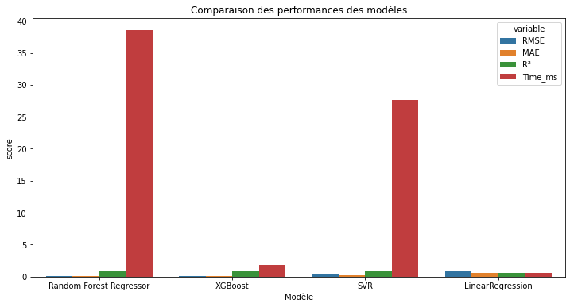

```python
plt.figure(figsize=(12,6))
sns.barplot(x = comparaison['Modèle'],
            y = comparaison['score'], hue = comparaison['variable'])
plt.title('Comparaison des performances des modèles')
```

Avec la projection graphique ci-dessus, on constate que le modèle XGBoost offre le meilleur compromis score / temps.

- Le modèle retenu pour la modélisation de la variable TotalGHGEmissions est donc le modèle XGBoost.

```python
xgb_grid_co2.best_params_
```

```
{'criterion': 'mse',
 'loss': 'ls',
 'max_features': 'auto',
 'min_samples_leaf': 1,
 'n_estimators': 300}
```

#### sauvegarde les paramètres de meilleur modèle

```python
best_param = xgb_grid_co2.best_params_

for i in best_param:
  best_param[i] = list([best_param[i]])

joblib.dump(best_param, 'best_param_xgb_CO2.sav')
```

```
['best_param_xgb_CO2.sav']
```

```python
#load saved model
# best_param = joblib.load(best_param_xgb_CO2.sav)
```

#### 5.Influence de la variable 'ENERGY STAR Score

Nous cherchons en particulier à évaluer l'intérêt de l’'ENERGY STAR Score' (www.energystar.gov) pour la prédiction d’émissions, qui est fastidieux à calculer avec l’approche utilisée actuellement par l'équipe.

Nous allons donc évaluer si ce score à un impact significatif sur les performances de notre modélisation.

```python
X_enS = X.copy()
```

```python
#Ajout de 'ENERGYSTARScore' aux variables X
X_enS['energy_star_score'] = energy_star_score
```

```python
y_enS = data_clean[['SiteEnergyUse(kBtu)','TotalGHGEmissions']]
```

```python
X_enS.head(1)
```

|  | NumberofBuildings | NumberofFloors | PropertyGFATotal | PropertyGFAParking | PropertyGFABuilding(s) | SiteEUI(kBtu/sf) | SourceEUI(kBtu/sf) | SteamUse(kBtu) | Electricity(kBtu) | NaturalGas(kBtu) | ... | x0_Lodging/Residential | x0_Mixed Use | x0_Office | x0_Other | x0_Public Assembly | x0_Retail | x0_Technology/Science | x0_Warehouse | x0_Warehouse/Storage | energy_star_score |
| --- | --- | --- | --- | --- | --- | --- | --- | --- | --- | --- | --- | --- | --- | --- | --- | --- | --- | --- | --- | --- | --- |
| 0 | -0.065008 | 0.654731 | 0.179007 | 0.573898 | 0.000832 | 0.040628 | 0.355316 | -0.18156 | 0.538503 | -0.161277 | ... | 0.0 | 0.0 | 1.0 | 0.0 | 0.0 | 0.0 | 0.0 | 0.0 | 0.0 | 45.0 |

1 rows × 28 columns

#### Standardisation de ENERGYSTARScore

```python
col_names = ['energy_star_score']
features = X_enS[col_names]
```

```python
scaler = StandardScaler().fit(features.values)
features = scaler.transform(features.values)
```

```python
X_enS[col_names] = features
```

```python
X_enS_train, X_enS_test, y_enS_train, y_enS_test = train_test_split(X_enS,y_enS['TotalGHGEmissions'], test_size=0.20,random_state=42)


print("Entrainement: {} lignes,\nTest: {} lignes.\n".format(X_enS_train.shape[0],
                                                            X_enS_test.shape[0]))
```

```
Entrainement: 1247 lignes,
Test: 312 lignes.
```

```python
Parameters = {
    'loss': ['ls'],
    'n_estimators': [300],
    'min_samples_leaf': [1],
    'max_features': ['auto'],
    'criterion': ['mse'],
}

xgb_grid_star = GridSearchCV(GradientBoostingRegressor(random_state=42),
                        param_grid = parameters,
                        scoring='neg_root_mean_squared_error',
                        n_jobs = -1,
                        cv = 5,
                        verbose=5)

xgb_grid_star.fit(X_enS_train, y_enS_train)
```

```
Fitting 5 folds for each of 60 candidates, totalling 300 fits
```

```
GridSearchCV(cv=5, estimator=GradientBoostingRegressor(random_state=42),
             n_jobs=-1,
             param_grid={'criterion': ['mse'], 'loss': ['ls', 'lad'],
                         'max_features': ['auto', 'sqrt'],
                         'min_samples_leaf': [1, 2, 5, 8, 12],
                         'n_estimators': [100, 200, 300]},
             scoring='neg_root_mean_squared_error', verbose=5)
```

```python
coefficients = abs(xgb_grid_star.best_estimator_.feature_importances_)
liste_coefs_rer = pd.concat((pd.DataFrame(X_enS.columns, columns = ['Variable']),
                      pd.DataFrame(coefficients, columns = ['Coefficient'])),
                       axis = 1).sort_values(by='Coefficient',
                                             ascending = False)
```

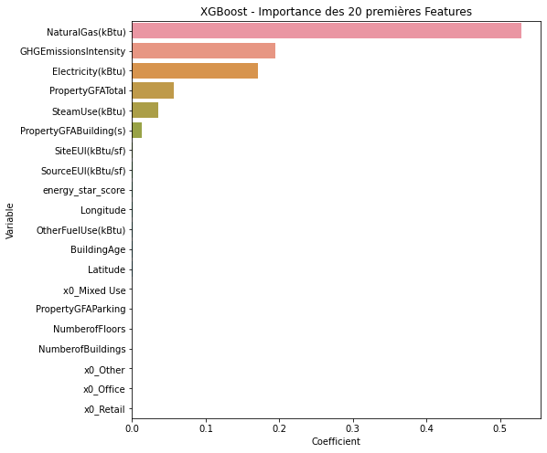

```python
plt.figure(figsize=(8,8))
plt.title('XGBoost - Importance des 20 premières Features')
sns.barplot(y = liste_coefs_rer['Variable'].head(20),
            x = liste_coefs_rer['Coefficient'].head(20))
plt.show()
```

```python
Energy_Star = pd.DataFrame({})

rmse = mean_squared_error(y_enS_test, xgb_grid_star.predict(X_enS_test), squared=False)
mae = mean_absolute_error(y_enS_test, xgb_grid_star.predict(X_enS_test))
r_squared = r2_score(y_enS_test, xgb_grid_star.predict(X_enS_test))
time = %timeit -o  xgb_grid_star.best_estimator_.predict(X_enS_test)

emissions_CO2 = emissions_CO2.append(pd.DataFrame({'Modèle': ['XGBoost_Energy_Star'],
                                       'RMSE': rmse,
                                       'MAE': mae,
                                       'R²': r_squared,
                                       'Time_ms': time.best*1000,
                    'Cv_score(RMSE)': -1 * xgb_grid_star.best_score_}),
                         ignore_index=True)
```

```
1.82 ms ± 70 µs per loop (mean ± std. dev. of 7 runs, 1000 loops each)
```

```python
emissions_CO2
```

|  | Modèle | RMSE | MAE | R² | Time_ms | Cv_score(RMSE) |
| --- | --- | --- | --- | --- | --- | --- |
| 0 | Random Forest Regressor | 0.093891 | 0.054754 | 0.994842 | 38.512940 | 0.127759 |
| 1 | XGBoost | 0.096436 | 0.067150 | 0.994559 | 1.777711 | 0.117061 |
| 2 | SVR | 0.309706 | 0.189208 | 0.943883 | 27.640650 | 0.342220 |
| 3 | LinearRegression | 0.883711 | 0.649457 | 0.543104 | 0.654558 | 0.777396 |
| 4 | XGBoost_Energy_Star | 0.094976 | 0.065890 | 0.994723 | 1.748621 | 0.114633 |

```python
emissions_CO2 = emissions_CO2.sort_values(by='R²', ascending=False)
emissions_CO2
```

|  | Modèle | RMSE | MAE | R² | Time_ms | Cv_score(RMSE) |
| --- | --- | --- | --- | --- | --- | --- |
| 0 | Random Forest Regressor | 0.093891 | 0.054754 | 0.994842 | 38.512940 | 0.127759 |
| 4 | XGBoost_Energy_Star | 0.094976 | 0.065890 | 0.994723 | 1.748621 | 0.114633 |
| 1 | XGBoost | 0.096436 | 0.067150 | 0.994559 | 1.777711 | 0.117061 |
| 2 | SVR | 0.309706 | 0.189208 | 0.943883 | 27.640650 | 0.342220 |
| 3 | LinearRegression | 0.883711 | 0.649457 | 0.543104 | 0.654558 | 0.777396 |

En ajoutant Energy Star Score à notre modèle, la performance du modèle s'améliore très légèrement.